# School data

The Department for Education’s [Edubase data set](https://get-information-schools.service.gov.uk/Downloads) contains basic information about every school in England and Wales. We are going to use it to explore some of the characteristcs of English schools. Let’s have a look at the attributes of the data set.

```r
# Load data set
# sch_data <- read.csv("edubasealldata20190911.csv")
# The dplyr library is great for data wrangling
library(dplyr)
# Remove closed schools
 sch_data_open <- sch_data  %>% filter(!EstablishmentStatus..name.=="Closed")
feats <- c("NumberOfPupils", "NumberOfBoys", "NumberOfGirls", "PhaseOfEducation..name.", "EstablishmentTypeGroup..name.", "EstablishmentName", "TypeOfEstablishment..name.", "Easting", "Northing", "AdmissionsPolicy..name.")
# Remove Welsh schools
 sch_data_en <- sch_data_open %>% filter(!sch_data_open$GOR..name.=="Wales (pseudo)")
sch_data_en <- sch_data_en[feats]
write.csv(sch_data_en, file = "sch_data_en.csv")
sch_data_en <- read.csv("sch_data_en.csv")
```

Most primary schools have under 500 pupils on roll and with a particuarly large number of schools having 200 to 250 pupils. Secondary schools typically have much larger rolls of between 500 and 1500 pupils.

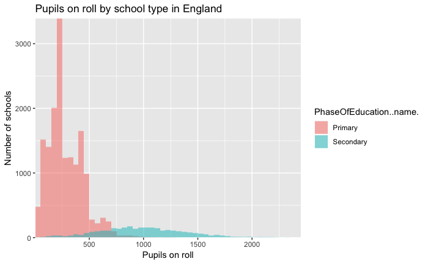

```r
library(ggplot2)
# Create new frame only where record contains pupil roll info
with_roll <- sch_data_en[!is.na(sch_data_en$NumberOfPupils),]
# New frame with only secondary and primary
with_roll2 <- filter(with_roll, PhaseOfEducation..name.=="Secondary" | PhaseOfEducation..name.=="Primary")
# Set breaks for plot
brks = round(seq(min(with_roll2$NumberOfPupils), 2500, by = 50),1)
# Histogram plot of primary and secondary school rolls
ggplot(with_roll2, aes(x=NumberOfPupils, fill=PhaseOfEducation..name.)) + geom_histogram(alpha=0.5, position="identity", breaks=brks) +   scale_x_continuous(name="Pupils on roll", expand = c(0, 0)) + scale_y_continuous(expand = c(0, 0)) + labs(x = "Pupil roll", y = "Number of schools", title="Pupils on roll by school type in England")
```

The Department for Education defines eight broad types of educational establishments. The most common tye of school are local authority maintained schools (mainly consisting of primary), followed by Academies. In this context universities refers to university technical colleges rather than traditional universities.

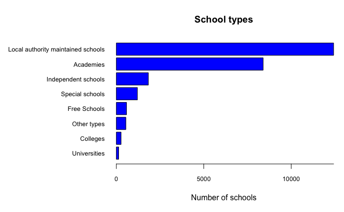

```r
 par(las=1) # Make label text perpendicular to axis
counts <- table(droplevels(sch_data_en$EstablishmentTypeGroup..name.))
par(mar=c(5,12,4,1)+.1) # Change margin so taables display properly
counts2  <- sort(counts) # Change order of bars
barplot(counts2, main="School types",
   xlab="Number of schools", horiz=TRUE, cex.names=0.8, axes=FALSE, col="blue")
axis(side=1, at=seq(0, 30000, by=5000), srt=90, cex.axis=0.8)
```

The overall girl-boy split is of little interest as it will mainly reflect the cohort at the time. However, looking at school types, we see special schools, alternative provision schools and university technical colleges tend to have a higher enrollment of boys. This is due to the fact boys are more likely to be excluded or otherwise have trouble in mainstream school than girls.

```r
# We are going to get the data we need this time using an SQL query using the sqldf library
library(sqldf)
# SQL doesn't like attribute names with dots so we will replicate this column using a new name
sch_data_en$SchoolType <- sch_data_en$TypeOfEstablishment..name.
# Here is the SQL query
gb_type <- sqldf('SELECT NumberOfBoys, NumberOfGirls, NumberOfPupils, SchoolType FROM sch_data_en')
collapsed <- gb_type %>% group_by(SchoolType) %>% summarise_at(vars(NumberOfGirls,NumberOfBoys,NumberOfPupils),funs(sum(.,na.rm=TRUE)))
```

```
funs() is soft deprecated as of dplyr 0.8.0
please use list() instead

# Before:
funs(name = f(.)

# After:
list(name = ~f(.))
```

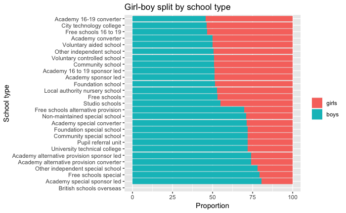

```r
collapsed$girls <- collapsed$NumberOfGirls / collapsed$NumberOfPupils * 100 # Proportion of boys
collapsed$boys <- collapsed$NumberOfBoys / collapsed$NumberOfPupils * 100
collapsed <- na.omit(collapsed) # Omit all NA values
row_sub = apply(collapsed, 1, function(row) all(row !=0 )) # Function to replace zero values
collapsed <- collapsed[row_sub,]
# Need another boys proportion attribute as will be using 'gather' in net step
collapsed$boys2 <- collapsed$NumberOfGirls / collapsed$NumberOfPupils * 100
library(tidyr)
collapsed %>%
   select(-NumberOfPupils) %>%
   gather(type, count, boys:girls) %>%

  ggplot(., aes(x=reorder(SchoolType, boys2), y = count, fill=forcats::fct_rev(type))) +
   geom_bar(stat="identity") + coord_flip() + ylab("Proportion") + labs(fill='', title = "Girl-boy split by school type", x = "School type")
```

England used to have a bipartite state education system consisting of selective “grammar schools”" and non-selective “secondary-modern schools”. The opening of this type of school was banned by the Labour government in 1965 and since then, many grammar schools converted to become “comprehensive”" (non-selective) school. Some local authorities successfully fought to retain their selective schools. Those which remain are shown in the map below.

```r
library(tmap)
library(tmaptools)
library(rgdal)
library(tmap)
library(tmaptools)
# Load shape file
regs2 <- readOGR(".", "Regions_December_2017_Super_Generalised_Clipped_Boundaries_in_England")
# Remove schools missing coordinates
sch_data2 <- sch_data_en[!is.na(sch_data_en$Easting),]
# Remove indepdenent schools
non_indep <- sch_data2[(sch_data2$EstablishmentTypeGroup..name. != "Independent schools"),]
# Get the selective
sel_sch <- non_indep[(non_indep$AdmissionsPolicy..name. == "Selective"),]
# Create new dataframe containing
d <- data.frame(lon=sel_sch$Easting, lat=sel_sch$Northing, name=sel_sch$EstablishmentName, pupils=sel_sch$NumberOfPupils)
# Define coordinates
coordinates(d) <- c("lon", "lat")
# Set projection
proj4string(d) <- CRS("+init=epsg:27700")
proj4string(regs2) <- CRS("+init=epsg:27700")
```

```
A new CRS was assigned to an object with an existing CRS:
+proj=tmerc +lat_0=49 +lon_0=-2 +k=0.9996012717 +x_0=400000 +y_0=-100000 +datum=OSGB36 +units=m +no_defs +ellps=airy +towgs84=446.448,-125.157,542.060,0.1502,0.2470,0.8421,-20.4894
without reprojecting.
For reprojection, use function spTransform
```

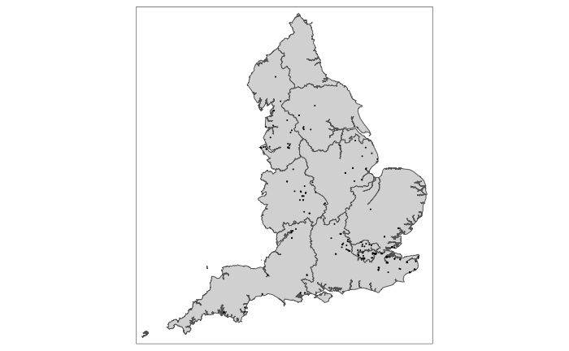

```r
# Plot selective schools
qtm(regs2) + qtm(d)
```